# MUSA508 Homework3:

Predictive Policing in Chicago, Illinois

Kristin Chang

October 23, 2020

# Introduction

Despite the prevalent bias present in predictive policing models, many cities utilize these types of algorithms to justify their decisions regarding allocation of resources and funding. This project breaks down the process of building one such algorithm while highlighting the issues that make its application problematic. This model will use past 2017 crime reports from the city of Chicago to predict future locations of unlawful cannabis possession.

The state of Illinois legalized sale of recreational marijuana January 1st of 2020 and has since observed a tax revenue of over $100 million according to the Chicago Tribune. Although sales are now legal, arrests can still be made for public consumption, driving under the influence, unlicensed sales, or possession on properties where the owners have banned its usage. The law change and these named caveats are two reasons why it is so difficult to predict where crime will happen.

Crimes such as unlawful possession of marijuana are influenced by a number of sociopolitical, environmental, and behavioral factors that are not necessarily tied to a location. Additionally, the factors that are seen as indicators of crime - for example, low income - are often actually outcomes of other underlying processes - for example, racism. An issue with the design of these types of models is that they can assume characteristics of a person make them more likely to commit a crime than another. This leaves large opportunities for bias and for models to be applied unfairly.

It is important to be aware of our own biases as we build and use such models and remain suspicious of their purposes.

# Setup

To begin, we import the necessary libraries and themes and define functions that will be used to create presentable maps.

```r
knitr::opts_chunk$set(echo=TRUE, warning=FALSE, message=FALSE, results='hide')
#install.packages("RSocrata")
#install.packages("spatstat")
library(tidyverse)
library(sf)
library(RSocrata)
library(viridis)
library(spatstat)
library(raster)
library(spdep)
library(FNN)
library(grid)
library(gridExtra)
library(knitr)
library(kableExtra)
library(tidycensus)
library(mapview)
# functions
root.dir = "https://raw.githubusercontent.com/urbanSpatial/Public-Policy-Analytics-Landing/master/DATA/"
source("https://raw.githubusercontent.com/urbanSpatial/Public-Policy-Analytics-Landing/master/functions.r")

options(scipen=999)

mapTheme <- function(base_size = 12) {
  theme(
    text = element_text( color = "black"),
    plot.title = element_text(size = 14,colour = "black"),
    plot.subtitle=element_text(face="italic"),
    plot.caption=element_text(hjust=0),
    axis.ticks = element_blank(),
    panel.background = element_blank(),axis.title = element_blank(),
    axis.text = element_blank(),
    axis.title.x = element_blank(),
    axis.title.y = element_blank(),
    panel.grid.minor = element_blank(),
    panel.border = element_rect(colour = "black", fill=NA, size=2)
  )
}

plotTheme <- function(base_size = 12) {
  theme(
    text = element_text( color = "black"),
    plot.title = element_text(size = 14,colour = "black"),
    plot.subtitle = element_text(face="italic"),
    plot.caption = element_text(hjust=0),
    axis.ticks = element_blank(),
    panel.background = element_blank(),
    panel.grid.major = element_line("grey80", size = 0.1),
    panel.grid.minor = element_blank(),
    panel.border = element_rect(colour = "black", fill=NA, size=2),
    strip.background = element_rect(fill = "grey80", color = "white"),
    strip.text = element_text(size=12),
    axis.title = element_text(size=12),
    axis.text = element_text(size=10),
    plot.background = element_blank(),
    legend.background = element_blank(),
    legend.title = element_text(colour = "black", face = "italic"),
    legend.text = element_text(colour = "black", face = "italic"),
    strip.text.x = element_text(size = 14)
  )
}

palette5 <- c("#25CB10", "#5AB60C", "#8FA108", "#C48C04", "#FA7800")
palette5_rev <- c("#8FA108", "#C48C04", "#FA7800", "#5AB60C", "#25CB10")

qBr <- function(df, variable, rnd) {
  if (missing(rnd)) {
    as.character(quantile(round(df[[variable]],0),
                          c(.01,.2,.4,.6,.8), na.rm=T))
  } else if (rnd == FALSE | rnd == F) {
    as.character(formatC(quantile(df[[variable]]), digits = 3),
                          c(.01,.2,.4,.6,.8), na.rm=T)
  }
}

qBr2 <- function(df, variable, rnd) { # quintile break for percentages
  if (missing(rnd)) {
    as.character(quantile(round(df[[variable]],2),
                          c(.01,.2,.4,.6,.8), na.rm=T))# breaks at the 1st, 20th, 40th, 60th, 80th
  } else if (rnd == FALSE | rnd == F) {
    as.character(formatC(quantile(df[[variable]]), digits = 3),
                 c(.01,.2,.4,.6,.8), na.rm=T)
  }
}

q5 <- function(variable) {as.factor(ntile(variable, 5))}

nn_function <- function(measureFrom,measureTo,k) {
  measureFrom_Matrix <-
    as.matrix(measureFrom)
  measureTo_Matrix <-
    as.matrix(measureTo)
  nn <-
    get.knnx(measureTo, measureFrom, k)$nn.dist
    output <-
      as.data.frame(nn) %>%
      rownames_to_column(var = "thisPoint") %>%
      gather(points, point_distance, V1:ncol(.)) %>%
      arrange(as.numeric(thisPoint)) %>%
      group_by(thisPoint) %>%
      summarize(pointDistance = mean(point_distance)) %>%
      arrange(as.numeric(thisPoint)) %>%
      dplyr::select(-thisPoint) %>%
      pull()

  return(output)
}
```

Next, we import geographies for police units, 2017 Chicago crime data, and a boundary of the city in order to plot the locations of reports of unlawful cannabis possession in 2017.

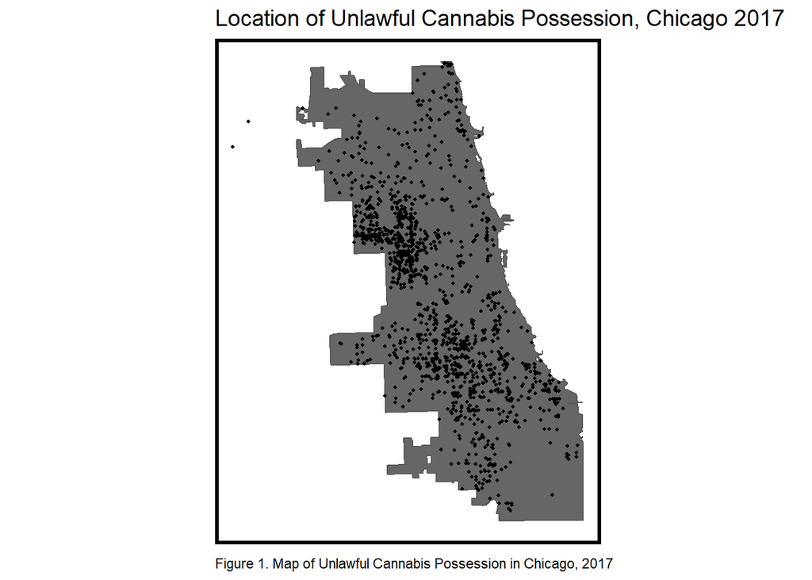

```r
policeDistricts <-
  st_read("https://data.cityofchicago.org/api/geospatial/fthy-xz3r?method=export&format=GeoJSON") %>%
  st_transform('ESRI:102271') %>%
  dplyr::select(District = dist_num)

policeBeats <-
  st_read("https://data.cityofchicago.org/api/geospatial/aerh-rz74?method=export&format=GeoJSON") %>%
  st_transform('ESRI:102271') %>%
  dplyr::select(District = beat_num)

bothPoliceUnits <- rbind(mutate(policeDistricts, Legend = "Police Districts"),
                         mutate(policeBeats, Legend = "Police Beats"))

# Primary Type is NARCOTICS and particularly the illegal possession Cannabis (aka Marijuana, weed).
crime_cannabis <-
  read.socrata("https://data.cityofchicago.org/Public-Safety/Crimes-2017/d62x-nvdr") %>%
    filter(Primary.Type == "NARCOTICS" & str_detect(Description, "POSS: CANNABIS") == T) %>%
    mutate(x = gsub("[()]", "", Location)) %>%
    separate(x,into= c("Y","X"), sep=",") %>%
    mutate(X = as.numeric(X),Y = as.numeric(Y)) %>%
    na.omit() %>%
    st_as_sf(coords = c("X", "Y"), crs = 4326, agr = "constant")%>%
    st_transform('ESRI:102271') %>%
    distinct()

chicagoBoundary <-
  st_read(file.path(root.dir,"/Chapter5/chicagoBoundary.geojson")) %>%
  st_transform('ESRI:102271')

ggplot(crime_cannabis[chicagoBoundary,]) +
  geom_sf(data = chicagoBoundary, fill = "grey40") +
  geom_sf(data = crime_cannabis,
          show.legend = "point", size = .75) +
  labs(title="Location of Unlawful Cannabis Possession, Chicago 2017",
       caption="Figure 1. Map of Unlawful Cannabis Possession in Chicago, 2017") +
  mapTheme()
```

Figure 1 shows a map of unlawful possession of cannabis in Chicago in 2017. There is some obvious clustering of where these crimes occurred. However, it is important to note that the clusters are in areas of Chicago that are heavily policed for their reputation of being dangerous. This is a common instance of selection bias that occurs in predictive policing models. Because the model is being trained based on crime reports, the prejudice present in how and where crimes are reported affect the reality of the model.

This may decrease the accuracy and reliability of the model because instead of truly analyzing the drivers of crime, it is merely echoing what is already assumed about these neighborhoods.

# Distribution of reports via fishnet grid

During our setup, we imported two geographical units (police beats and police districts) to help describe which areas of Chicago are more at risk for this type of crime. However, these boundaries are not consistent across space in terms of their populations and are not an appropriate unit for crime risk. Instead, we will use a fishnet grid to visualize clusters as hot spots.

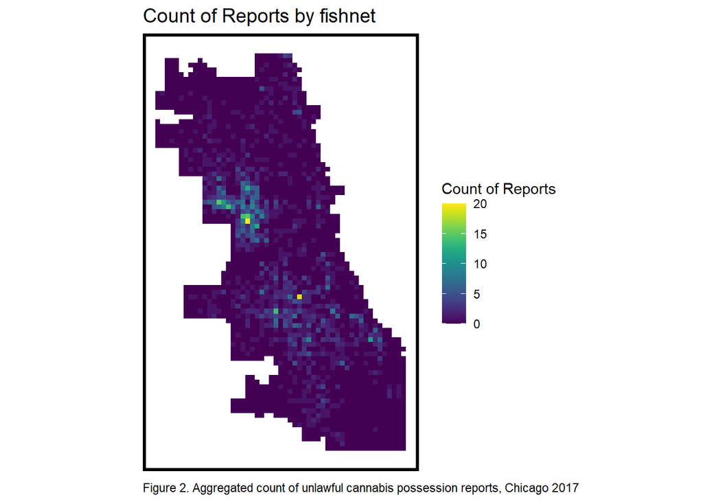

```r
fishnet <-
  st_make_grid(chicagoBoundary,
               cellsize = 500,
               square = TRUE) %>%
  .[chicagoBoundary] %>%
  st_sf() %>%
  mutate(uniqueID = rownames(.))

## add a value of 1 to each crime, sum them with aggregate
crime_net <-
  dplyr::select(crime_cannabis) %>%
  mutate(countCrime = 1) %>%
  aggregate(., fishnet, sum) %>%
  mutate(countCrime = replace_na(countCrime, 0),
         uniqueID = rownames(.),
         cvID = sample(round(nrow(fishnet) / 24),
                       size=nrow(fishnet), replace = TRUE)) #for cross validation

# 2. A map of your outcome joined to the fishnet
ggplot() +
  geom_sf(data = crime_net, aes(fill = countCrime), color = NA) +
  scale_fill_viridis() +
  labs(title = "Count of Reports by fishnet",
       fill = "Count of Reports",
       caption="Figure 2. Aggregated count of unlawful cannabis possession reports, Chicago 2017") +
  mapTheme()
```

The map now shows the count of unlawful cannabis possession reports joined to the fishnet grid.

# Risk factors

This next section is where will identify and select features of Chicago that would likely lead to unlawful cannabis possession. This is a primary section where selection bias is present due to the Broken Windows Theory. The theory asserts that there is a connection between “disorderly” communities and crime. Namely, that crime is more prevalent in communities appearing poor in either physical, economic, or health conditions.

The factors selected fall in line with this theory because they are characteristics of blight and low-income communities and thus, are subject to bias. We import data for abandoned cars and buildings, graffiti, broken street lights, sanitation, police stations, liquor retail, affordable housing, and public schools.

```r
abandonCars <-
  read.socrata("https://data.cityofchicago.org/Service-Requests/311-Service-Requests-Abandoned-Vehicles/3c9v-pnva") %>%
    mutate(year = substr(creation_date,1,4)) %>% filter(year == "2017") %>%
    dplyr::select(Y = latitude, X = longitude) %>%
    na.omit() %>%
    st_as_sf(coords = c("X", "Y"), crs = 4326, agr = "constant") %>%
    st_transform(st_crs(fishnet)) %>%
    mutate(Legend = "Abandoned_Cars")

abandonBuildings <-
  read.socrata("https://data.cityofchicago.org/Service-Requests/311-Service-Requests-Vacant-and-Abandoned-Building/7nii-7srd") %>%
    mutate(year = substr(date_service_request_was_received,1,4)) %>%  filter(year == "2017") %>%
    dplyr::select(Y = latitude, X = longitude) %>%
    na.omit() %>%
    st_as_sf(coords = c("X", "Y"), crs = 4326, agr = "constant") %>%
    st_transform(st_crs(fishnet)) %>%
    mutate(Legend = "Abandoned_Buildings")

graffiti <-
  read.socrata("https://data.cityofchicago.org/Service-Requests/311-Service-Requests-Graffiti-Removal-Historical/hec5-y4x5") %>%
    mutate(year = substr(creation_date,1,4)) %>% filter(year == "2017") %>%
    filter(where_is_the_graffiti_located_ %in% c("Front", "Rear", "Side")) %>%
    dplyr::select(Y = latitude, X = longitude) %>%
    na.omit() %>%
    st_as_sf(coords = c("X", "Y"), crs = 4326, agr = "constant") %>%
    st_transform(st_crs(fishnet)) %>%
    mutate(Legend = "Graffiti")

streetLightsOut <-
  read.socrata("https://data.cityofchicago.org/Service-Requests/311-Service-Requests-Street-Lights-All-Out/zuxi-7xem") %>%
    mutate(year = substr(creation_date,1,4)) %>% filter(year == "2017") %>%
    dplyr::select(Y = latitude, X = longitude) %>%
    na.omit() %>%
    st_as_sf(coords = c("X", "Y"), crs = 4326, agr = "constant") %>%
    st_transform(st_crs(fishnet)) %>%
    mutate(Legend = "Street_Lights_Out")

sanitation <-
  read.socrata("https://data.cityofchicago.org/Service-Requests/311-Service-Requests-Sanitation-Code-Complaints-Hi/me59-5fac") %>%
    mutate(year = substr(creation_date,1,4)) %>% filter(year == "2017") %>%
    dplyr::select(Y = latitude, X = longitude) %>%
    na.omit() %>%
    st_as_sf(coords = c("X", "Y"), crs = 4326, agr = "constant") %>%
    st_transform(st_crs(fishnet)) %>%
    mutate(Legend = "Sanitation")

liquorRetail <-
  read.socrata("https://data.cityofchicago.org/resource/nrmj-3kcf.json") %>%
    filter(business_activity == "Retail Sales of Packaged Liquor") %>%
    dplyr::select(Y = latitude, X = longitude) %>%
    na.omit() %>%
    st_as_sf(coords = c("X", "Y"), crs = 4326, agr = "constant") %>%
    st_transform(st_crs(fishnet)) %>%
    mutate(Legend = "Liquor_Retail")

policeStation <-
  read.socrata("https://data.cityofchicago.org/resource/z8bn-74gv.json") %>%
    dplyr::select(Y = latitude, X = longitude) %>%
    na.omit() %>%
    st_as_sf(coords = c("X", "Y"), crs = 4326, agr = "constant") %>%
    st_transform(st_crs(fishnet)) %>%
    mutate(Legend = "Police_Station") #2016

#The rental housing developments listed below are among the thousands of affordable units that are supported by City of Chicago programs to maintain affordability in local neighborhoods. No specific dates in dataset.
affordableRental <-
  read.socrata("https://data.cityofchicago.org/resource/s6ha-ppgi.json") %>%
    dplyr::select(Y = latitude, X = longitude) %>%
    na.omit() %>%
    st_as_sf(coords = c("X", "Y"), crs = 4326, agr = "constant") %>%
    st_transform(st_crs(fishnet)) %>%
    mutate(Legend = "Affordable_Rental_Housing")

# Public Schools in Cook County, SY2017-18
publicSchools <-
  read.socrata("https://data.cityofchicago.org/resource/d2h8-2upd.json") %>%
    filter(str_detect(grades,"12")==T) %>%
    dplyr::select(Y = lat, X = long) %>%
    na.omit() %>%
    st_as_sf(coords = c("X", "Y"), crs = 4326, agr = "constant") %>%
    st_transform(st_crs(fishnet)) %>%
    mutate(Legend = "Public_Schools")
```

```r
vars_net <-
  rbind(abandonCars,streetLightsOut,abandonBuildings,
        liquorRetail, graffiti, sanitation, policeStation, affordableRental, publicSchools) %>%
  st_join(., fishnet, join=st_within) %>%
  st_drop_geometry() %>%
  group_by(uniqueID, Legend) %>%
  summarize(count = n()) %>%
    full_join(fishnet) %>%
    spread(Legend, count, fill=0) %>%
    st_sf() %>%
    dplyr::select(-`<NA>`) %>%
    na.omit() %>%
    ungroup()

vars_net.long <-
  gather(vars_net, Variable, value, -geometry, -uniqueID)

vars <- unique(vars_net.long$Variable)
mapList <- list()

for(i in vars){
  mapList[[i]] <-
    ggplot() +
      geom_sf(data = filter(vars_net.long, Variable == i), aes(fill=value), colour=NA) +
      scale_fill_viridis(name="") +
      labs(title=i) +
      mapTheme()}

#do.call(grid.arrange,c(mapList, ncol =4, top = "Risk Factors by Fishnet", bottom = "Figure 3"))
```

We then engineer these features using the nearest neighbor function so that we can relate them to crime risk. Additionally, we plot each feature on a fishnet as we did with the aggregated crime data.

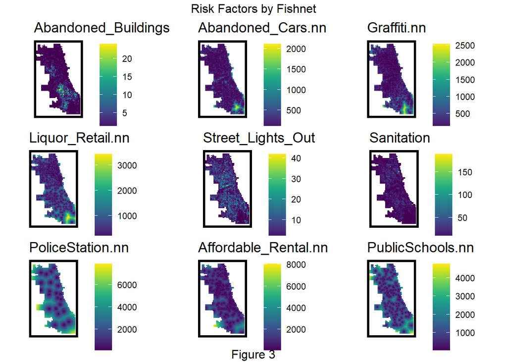

```r
## Neighborhoods to use in LOGOCV in a bit
neighborhoods <-
  st_read("https://raw.githubusercontent.com/blackmad/neighborhoods/master/chicago.geojson") %>%
  st_transform(st_crs(fishnet))

st_c <- st_coordinates
st_coid <- st_centroid

vars_net <-
  vars_net %>%
    mutate(
      Abandoned_Buildings.nn =
        nn_function(st_c(st_coid(vars_net)), st_c(abandonBuildings),1),
      Abandoned_Cars.nn =
        nn_function(st_c(st_coid(vars_net)), st_c(abandonCars),1),
      Graffiti.nn =
        nn_function(st_c(st_coid(vars_net)), st_c(graffiti),1),
      Liquor_Retail.nn =
        nn_function(st_c(st_coid(vars_net)), st_c(liquorRetail),1),
      Street_Lights_Out.nn =
        nn_function(st_c(st_coid(vars_net)), st_c(streetLightsOut),1),
      Sanitation.nn =
        nn_function(st_c(st_coid(vars_net)), st_c(sanitation),1),
      PoliceStation.nn =
        nn_function(st_c(st_coid(vars_net)), st_c(policeStation),1),
      Affordable_Rental.nn =
        nn_function(st_c(st_coid(vars_net)), st_c(affordableRental),1),
      PublicSchools.nn =
        nn_function(st_c(st_coid(vars_net)), st_c(publicSchools),1))

vars_net.long.nn <-
  dplyr::select(vars_net, ends_with(".nn")) %>%
    gather(Variable, value, -geometry)

vars <- unique(vars_net.long.nn$Variable)
mapList <- list()

for(i in vars){
  mapList[[i]] <-
    ggplot() +
      geom_sf(data = filter(vars_net.long.nn, Variable == i), aes(fill=value), colour=NA) +
      scale_fill_viridis(name="") +
      labs(title=i) +
      mapTheme()}

loopPoint <-
  filter(neighborhoods, name == "Loop") %>%
  st_centroid()

vars_net$loopDistance =
  st_distance(st_centroid(vars_net),loopPoint) %>%
  as.numeric()

# 3. A small multiple map of your risk factors in the fishnet (engineered)
final_vars_net.long <-
  dplyr::select(vars_net, Abandoned_Buildings, Abandoned_Cars.nn, Graffiti.nn,
              Liquor_Retail.nn, Street_Lights_Out, Sanitation, PoliceStation.nn, Affordable_Rental.nn, PublicSchools.nn) %>%
    gather(Variable, value, -geometry)

vars <- unique(final_vars_net.long$Variable)
mapList <- list()

for(i in vars){
  mapList[[i]] <-
    ggplot() +
      geom_sf(data = filter(final_vars_net.long, Variable == i), aes(fill=value), colour=NA) +
      scale_fill_viridis(name="") +
      labs(title=i) +
      mapTheme()}

do.call(grid.arrange,c(mapList, ncol = 3, top = "Risk Factors by Fishnet", bottom = "Figure 3"))
```

These fishnets allow us to see the spatial processes present in each of our chosen risk factors. Abandoned buildings, abandoned cars, and graffiti show obvious clustering whereas the other features show mixed patterns of clustering and dispersion.

We later will look at the correlation between these factors and our dependent variable - reports of unlawful possession of cannabis.

# Spatial process of depedent variable

After gaining an understanding of the spatial processes of our selected risk factors, we explore the spatial process of the crime itself by calculating a statistic known as Local Moran’s I. The Local Moran’s I utilizes a spatial weights matrix to relate each grid cell in the fishnet with its neighbors. The output along with other helpful statistics are presented below:

```r
# Join risk factors
final_net <-
  left_join(crime_net, st_drop_geometry(vars_net), by="uniqueID")
# Join neighborhoods and police districts
final_net <-
  st_centroid(final_net) %>%
    st_join(dplyr::select(neighborhoods, name)) %>%
    st_join(dplyr::select(policeDistricts, District)) %>%
      st_drop_geometry() %>%
      left_join(dplyr::select(final_net, geometry, uniqueID)) %>%
      st_sf() %>%
  na.omit()
```

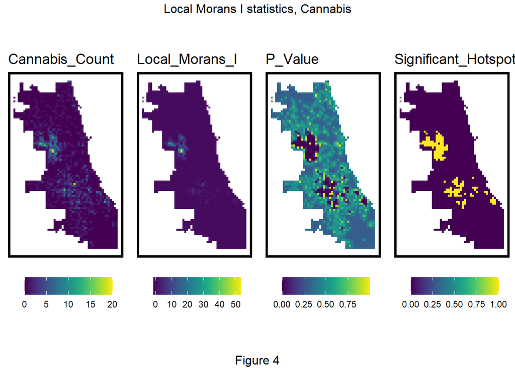

```r
# 4. Local Moran's I-related small multiple map of your outcome
final_net.nb <- poly2nb(as_Spatial(final_net), queen=TRUE)
final_net.weights <- nb2listw(final_net.nb, style="W", zero.policy=TRUE)

final_net.localMorans <-
  cbind(
    as.data.frame(localmoran(final_net$countCrime, final_net.weights)),
    as.data.frame(final_net)) %>%
    st_sf() %>%
      dplyr::select(Cannabis_Count = countCrime,
                    Local_Morans_I = Ii,
                    P_Value = `Pr(z > 0)`) %>%
      mutate(Significant_Hotspots = ifelse(P_Value <= 0.05, 1, 0)) %>%
      gather(Variable, Value, -geometry)

vars <- unique(final_net.localMorans$Variable)
varList <- list()

for(i in vars){
  varList[[i]] <-
    ggplot() +
      geom_sf(data = filter(final_net.localMorans, Variable == i),
              aes(fill = Value), colour=NA) +
      scale_fill_viridis(name="") +
      labs(title=i) +
      mapTheme() + theme(legend.position="bottom")}

do.call(grid.arrange,c(varList, ncol = 4, top = "Local Morans I statistics, Cannabis", bottom = "Figure 4"))
```

Figure 4 displays the first fishnet of “Count of Reports” renamed Cannabis_Count, the results of our Local Moran’s I test, the distribution of the p-value and significant hotspots. High values of Local Moran’s I indicates strong evidence of local clustering that was also observed in the aggregated count map. The low p-values indicate that these values of I are statistically significant in the same areas as well.

These four maps together indicate that there is strong clustering at play with our dependent variable. This implicates that our model will need to control for this spatial process in order to be generalizable across both hotspot and coldspot areas.

The map below uses the above identfied hotspots to assign a value to each grid cell based on its distance to a hotspot.

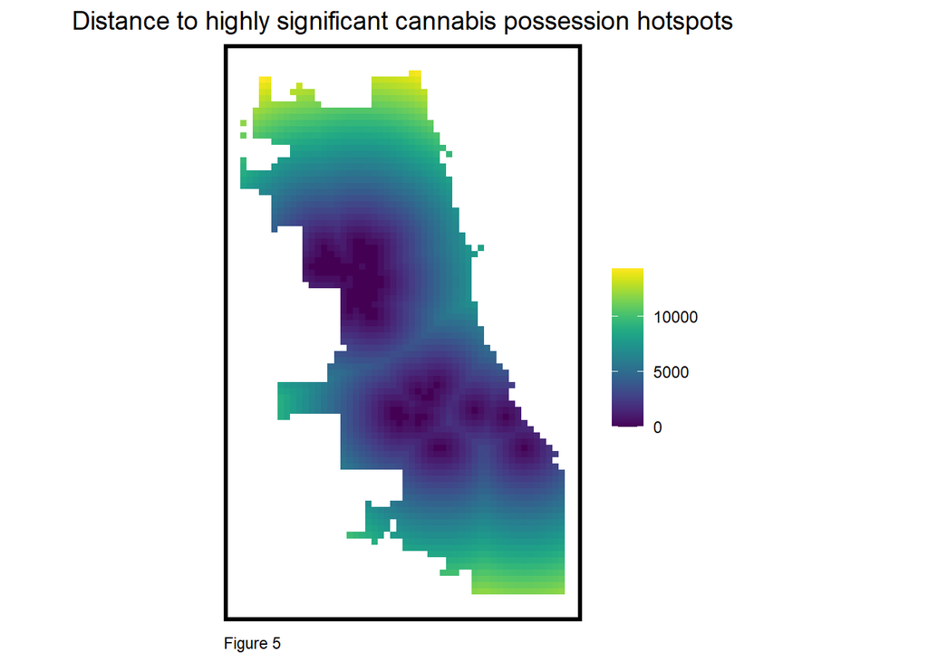

```r
final_net <-
  final_net %>%
  mutate(cannabis.isSig =
           ifelse(localmoran(final_net$countCrime,
                             final_net.weights)[,5] <= 0.0000001, 1, 0)) %>%
  mutate(cannabis.isSig.dist =
           nn_function(st_coordinates(st_centroid(final_net)),
                       st_coordinates(st_centroid(
                         filter(final_net, cannabis.isSig == 1))), 1))
ggplot()+
  geom_sf(data=final_net, aes(fill = cannabis.isSig.dist), colour=NA) +
      scale_fill_viridis(name="")+
  labs(title="Distance to highly significant cannabis possession hotspots",
       caption="Figure 5")+
  mapTheme()+theme(plot.title=element_text(hjust=0.5))
```

# Correlation tests

Now that we are aware of the spatial process of our dependent variable and our risk factors, we can observe their relationships to one another. This is done by calculating the Pearson R correlation for each of our selected risk factors.

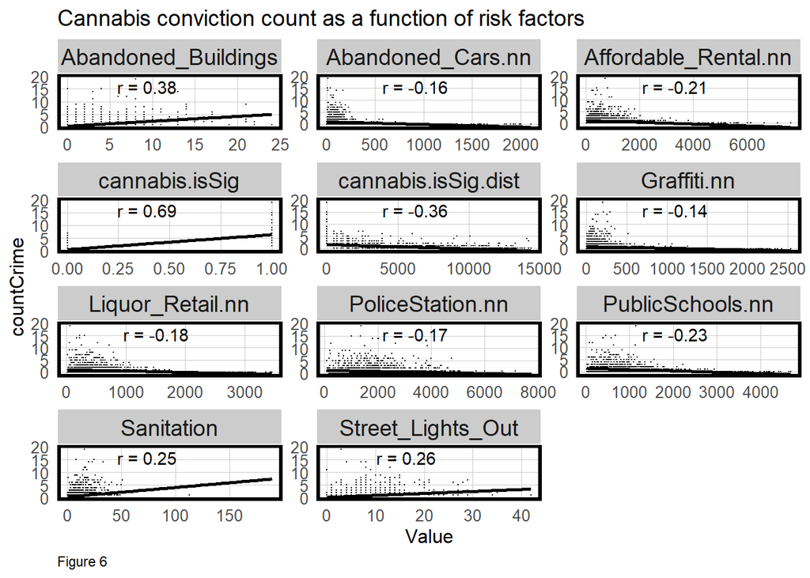

```r
# 5. A small multiple scatterplot with correlations
plot_vars <- c("Abandoned_Buildings", "Abandoned_Cars.nn", "Graffiti.nn",
              "Liquor_Retail.nn", "Street_Lights_Out", "Sanitation", "PoliceStation.nn", "Affordable_Rental.nn", "PublicSchools.nn", "cannabis.isSig", "cannabis.isSig.dist")

correlation.long <-
  st_drop_geometry(final_net) %>%
    dplyr::select(-uniqueID, -cvID, -name, -District) %>%
    gather(Variable, Value, -countCrime) %>%
    filter(Variable %in% plot_vars)

correlation.cor <-
  correlation.long %>%
    group_by(Variable) %>%
    summarize(correlation = cor(Value, countCrime, use = "complete.obs"))

ggplot(correlation.long, aes(Value, countCrime)) +
  geom_point(size = 0.1) +
  geom_text(data = correlation.cor, aes(label = paste("r =", round(correlation, 2))),
            x=-Inf, y=Inf, vjust = 1.5, hjust = -1) +
  geom_smooth(method = "lm", se = FALSE, colour = "black") +
  facet_wrap(~Variable, ncol = 3, scales = "free") +
  labs(title = "Cannabis conviction count as a function of risk factors",
       caption = "Figure 6") +
  plotTheme()
```

These correlation scatterplots were helpful in selecting our features because we were able to use each value of r to determine how strong the relationship is with the dependent variable. However, we also needed to consider that in multivariate regression the risk factors’ correlations will be affected by their relationships with one another. Thus, we could not select the features solely based on this Pearson correlation test, but had to observe how they would affect our regression model as well.

# Histogram of dependent variable

To determine the type of regression model we will use, we first create a histogram of our dependent variable.

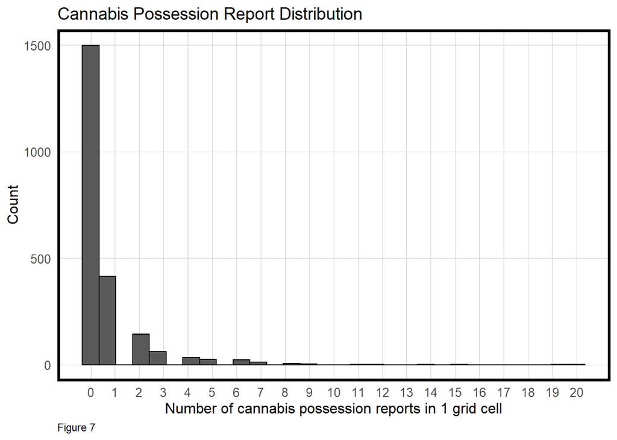

```r
# 6. A histogram of your dependent variable
final_net %>%
  ggplot(aes(countCrime)) +
    geom_histogram(bins = 30, colour="black") +
  scale_x_continuous(breaks = seq(0, 20, by = 1)) +
    labs(title="Cannabis Possession Report Distribution",
         x="Number of cannabis possession reports in 1 grid cell", y="Count",
         caption = "Figure 7") +
  plotTheme()
```

Because the distribution of our dependent variable is not normal, OLS regression is inappropriate. Instead, we will utilize cross-validated Poisson regression.

# Cross-Validated Poisson Regression

In this section, we will perform a k-fold variation of the chosen cross-validated poisson regression method. This involves the “Leave-one-group-out” cross-validation or LOGO-CV in which each neighborhood will take a turn being the test dataset while the remaining neighborhoods will serve as the training dataset.

```r
crossValidate <- function(dataset, id, dependentVariable, indVariables) {

allPredictions <- data.frame()
cvID_list <- unique(dataset[[id]])

for (i in cvID_list) {

  thisFold <- i
  cat("This hold out fold is", thisFold, "\n")

  fold.train <- filter(dataset, dataset[[id]] != thisFold) %>% as.data.frame() %>%
                dplyr::select(id, geometry, indVariables, dependentVariable)
  fold.test  <- filter(dataset, dataset[[id]] == thisFold) %>% as.data.frame() %>%
                dplyr::select(id, geometry, indVariables, dependentVariable)

  regression <-
    glm(countCrime ~ ., family = "poisson",
      data = fold.train %>%
      dplyr::select(-geometry, -id))

  thisPrediction <-
    mutate(fold.test, Prediction = predict(regression, fold.test, type = "response"))

  allPredictions <-
    rbind(allPredictions, thisPrediction)

  }
  return(st_sf(allPredictions))
}
```

We perform this regression four different times. Once using the neighborhood names to distinguish the hold-outs and once using more randomized groups (assigned a unique ID number) as the hold-outs.

For each set of groups, we perform the regression on two sets of variables - one set contains the spatial process calculations from our Local Moran’s I test while the other contains just the risk factors themselves.

```r
reg.cv <- crossValidate(
  dataset = final_net,
  id = "cvID",
  dependentVariable = "countCrime",
  indVariables = reg.vars) %>%
    dplyr::select(cvID = cvID, countCrime, Prediction, geometry)

reg.ss.cv <- crossValidate(
  dataset = final_net,
  id = "cvID",
  dependentVariable = "countCrime",
  indVariables = reg.ss.vars) %>%
    dplyr::select(cvID = cvID, countCrime, Prediction, geometry)

reg.spatialCV <- crossValidate(
  dataset = final_net,
  id = "name",
  dependentVariable = "countCrime",
  indVariables = reg.vars) %>%
    dplyr::select(cvID = name, countCrime, Prediction, geometry)

reg.ss.spatialCV <- crossValidate(
  dataset = final_net,
  id = "name",
  dependentVariable = "countCrime",
  indVariables = reg.ss.vars) %>%
    dplyr::select(cvID = name, countCrime, Prediction, geometry)
```

# Analyzing Errors

The resulting predictions from the model can be compared to observations in our original 2017 data to calculate mean absolute errors (MAEs) of each prediction. The distribution of MAEs will indicate the level of generalizability of the models across space.

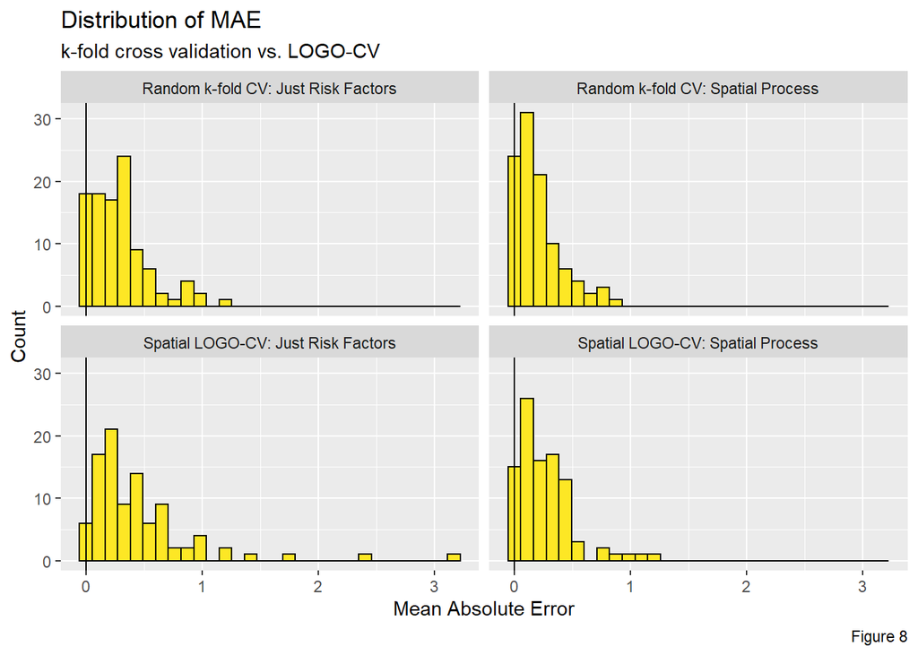

```r
reg.summary <-
  rbind(
    mutate(reg.cv,           Error = Prediction - countCrime,
                             Regression = "Random k-fold CV: Just Risk Factors"),

    mutate(reg.ss.cv,        Error = Prediction - countCrime,
                             Regression = "Random k-fold CV: Spatial Process"),

    mutate(reg.spatialCV,    Error = Prediction - countCrime,
                             Regression = "Spatial LOGO-CV: Just Risk Factors"),

    mutate(reg.ss.spatialCV, Error = Prediction - countCrime,
                             Regression = "Spatial LOGO-CV: Spatial Process")) %>%
    st_sf()

error_by_reg_and_fold <-
  reg.summary %>%
    group_by(Regression, cvID) %>%
    summarize(Mean_Error = mean(Prediction - countCrime, na.rm = T),
              MAE = mean(abs(Mean_Error), na.rm = T),
              SD_MAE = mean(abs(Mean_Error), na.rm = T)) %>%
  ungroup()

error_by_reg_and_fold %>%
  ggplot(aes(MAE)) +
    geom_histogram(bins = 30, colour="black", fill = "#FDE725FF") +
    facet_wrap(~Regression) +
    geom_vline(xintercept = 0) + scale_x_continuous(breaks = seq(0, 8, by = 1)) +
    labs(title="Distribution of MAE",
         subtitle = "k-fold cross validation vs. LOGO-CV",
         x="Mean Absolute Error", y="Count",
         caption = "Figure 8")
```

Figure 8 shows the distribution of Mean Absolute Error across neighborhoods. We observe that when just the risk factors are included in either k-fold or LOGO-CV fold, there are higher errors. However, when spatial process features are included in the model, those errors are minimized.

```r
# 8. A table of MAE and standard deviation MAE by regression
st_drop_geometry(error_by_reg_and_fold) %>%
  group_by(Regression) %>%
    summarize(Mean_MAE = round(mean(MAE), 2),
              SD_MAE = round(sd(MAE), 2)) %>%
  kable(caption = "MAE by regression") %>%
    kable_styling("striped", full_width = F) %>%
    row_spec(2, color = "black", background = "#8FA108") %>%
    row_spec(4, color = "black", background = "#8FA108")
```

Next we create a series of maps to visualize the errors of the four regressions.

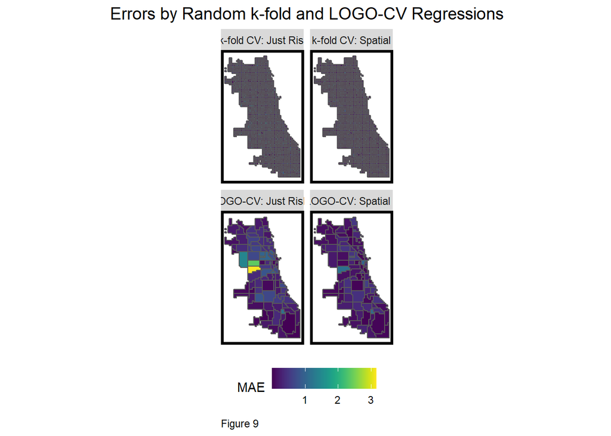

```r
error_by_reg_and_fold %>%
  ggplot() +
    geom_sf(aes(fill = MAE)) +
    facet_wrap(~Regression) +
    scale_fill_viridis() +
    labs(title = "Errors by Random k-fold and LOGO-CV Regressions", caption="Figure 9") +
    mapTheme() + theme(plot.title=element_text(hjust=0.5),legend.position="bottom")
```

To test for any spatial autocorrelation in these model errors, we create a new spatial weights matrix at the neighborhood level instead of the grid cell level as we had done earlier. We then can calculate a Global Moran’s I and p-values for each LOGO-CV regression.

```r
neighborhood.weights <-
  filter(error_by_reg_and_fold, Regression == "Spatial LOGO-CV: Spatial Process") %>%
    group_by(cvID) %>%
      poly2nb(as_Spatial(.), queen=TRUE) %>%
      nb2listw(., style="W", zero.policy=TRUE)

filter(error_by_reg_and_fold, str_detect(Regression, "LOGO"))  %>%
    st_drop_geometry() %>%
    group_by(Regression) %>%
    summarize(Morans_I = moran.mc(abs(Mean_Error), neighborhood.weights,
                                 nsim = 999, zero.policy = TRUE,
                                 na.action=na.omit)[[1]],
              p_value = moran.mc(abs(Mean_Error), neighborhood.weights,
                                 nsim = 999, zero.policy = TRUE,
                                 na.action=na.omit)[[3]]) %>%
  kable(caption = "Spatial LOGO-CV: Spatial Process") %>%
    kable_styling("striped", full_width = F) %>%
    row_spec(2, color = "black", background = "#8FA108")
```

# Generalizability by neighborhood context

We then can re-calculate the MAE of each of our four models under the context of White and non-White racial groups.

```r
# 9. A table of raw errors by race context for a random k-fold and spatial cross validation
# Why use 2018 not 2017?
# Ken's reply: The reason is b/c we hope to create a generalizable resource allocation tool. Thus a reasonable test is to see how well 2017 predictions generalize to 2018. If they don't, then it's not likely a good decision making tool.
#We can reasonably assume that the crime patterns haven't changed much in Chicago between 2017 and 2018. Consider if this assumption holds for example, before and after COVID onset.
tracts18 <-
  get_acs(geography = "tract", variables = c("B01001_001E","B01001A_001E"),
          year = 2018, state=17, county=031, geometry=T) %>%
  st_transform('ESRI:102271')  %>%
  dplyr::select(variable, estimate, GEOID) %>%
  spread(variable, estimate) %>%
  rename(TotalPop = B01001_001,
         NumberWhites = B01001A_001) %>%
  mutate(percentWhite = NumberWhites / TotalPop,
         raceContext = ifelse(percentWhite > .5, "Majority_White", "Majority_Non_White")) %>%
  .[neighborhoods,]

reg.summary %>%
    st_centroid() %>%
    st_join(tracts18) %>%
    na.omit() %>%
      st_drop_geometry() %>%
      group_by(Regression, raceContext) %>%
      summarize(mean.Error = mean(Error, na.rm = T)) %>%
      spread(raceContext, mean.Error) %>%
      kable(caption = "MAE by neighborhood racial context") %>%
        kable_styling("striped", full_width = F) %>%
    row_spec(2, color = "black", background = "#8FA108") %>%
    row_spec(4, color = "black", background = "#8FA108")
```

# Model comparison: risk prediction vs. hotspot mapping

While the models we have created focus on predicting risk, many police departments rely on mapping density to target areas with high concentrations or hotspots of crime. This method is known as “Kernel Density” hotspot mapping.

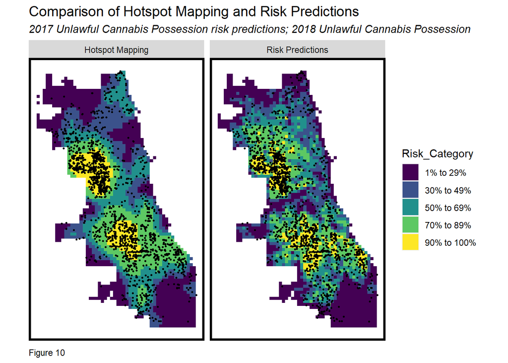

```r
# 10. The map comparing kernel density to risk predictions for the 2018 crime
# setting up dataset for crime_cannabis in 2018
cannabis18 <-
  read.socrata("https://data.cityofchicago.org/Public-Safety/Crimes-2018/3i3m-jwuy") %>%
  filter(Primary.Type == "NARCOTICS" & str_detect(Description, "POSS: CANNABIS") == T) %>%
    mutate(x = gsub("[()]", "", Location)) %>%
    separate(x,into= c("Y","X"), sep=",") %>%
    mutate(X = as.numeric(X),Y = as.numeric(Y)) %>%
    na.omit() %>%
    st_as_sf(coords = c("X", "Y"), crs = 4326, agr = "constant")%>%
    st_transform('ESRI:102271') %>%
    distinct() %>%
  .[fishnet,]

# calculating kernel density for crime_cannabis in 2017 and adds count of cannabis2018
cann_ppp <- as.ppp(st_coordinates(crime_cannabis), W = st_bbox(final_net))
cann_KD <- spatstat::density.ppp(cann_ppp, 1000)

cann_KDE_sf <- as.data.frame(cann_KD) %>%
  st_as_sf(coords = c("x", "y"), crs = st_crs(final_net)) %>%
  aggregate(., final_net, mean) %>%
  mutate(label = "Hotspot Mapping",
         Risk_Category = ntile(value, 100),
         Risk_Category = case_when(
           Risk_Category >= 90 ~ "90% to 100%",
           Risk_Category >= 70 & Risk_Category <= 89 ~ "70% to 89%",
           Risk_Category >= 50 & Risk_Category <= 69 ~ "50% to 69%",
           Risk_Category >= 30 & Risk_Category <= 49 ~ "30% to 49%",
           Risk_Category >= 1 & Risk_Category <= 29 ~ "1% to 29%")) %>%
  cbind(
    aggregate(
      dplyr::select(cannabis18) %>% mutate(cannCount = 1), ., sum) %>%
    mutate(cannCount = replace_na(cannCount, 0))) %>%
  dplyr::select(label, Risk_Category, cannCount)

#repeat for risk prediction
cann_risk_sf <-
  filter(reg.summary, Regression == "Spatial LOGO-CV: Spatial Process") %>%
  mutate(label = "Risk Predictions",
         Risk_Category = ntile(Prediction, 100),
         Risk_Category = case_when(
           Risk_Category >= 90 ~ "90% to 100%",
           Risk_Category >= 70 & Risk_Category <= 89 ~ "70% to 89%",
           Risk_Category >= 50 & Risk_Category <= 69 ~ "50% to 69%",
           Risk_Category >= 30 & Risk_Category <= 49 ~ "30% to 49%",
           Risk_Category >= 1 & Risk_Category <= 29 ~ "1% to 29%")) %>%
  cbind(
    aggregate(
      dplyr::select(cannabis18) %>% mutate(cannCount = 1), ., sum) %>%
      mutate(cannCount = replace_na(cannCount, 0))) %>%
  dplyr::select(label,Risk_Category, cannCount)

# map comparing kernel density to risk predictions for the 2018 crime
rbind(cann_KDE_sf, cann_risk_sf) %>%
  na.omit() %>%
  gather(Variable, Value, -label, -Risk_Category, -geometry) %>%
  ggplot() +
    geom_sf(aes(fill = Risk_Category), colour = NA) +
    geom_sf(data = sample_n(cannabis18, 2032), size = .5, colour = "black") +
    facet_wrap(~label, ) +
    scale_fill_viridis(discrete = TRUE) +
    labs(title="Comparison of Hotspot Mapping and Risk Predictions",
         subtitle="2017 Unlawful Cannabis Possession risk predictions; 2018 Unlawful Cannabis Possession",
         caption="Figure 10") +
    mapTheme()
```

Figure 10 allows us to compare the two methods. We can see that the risk predictions method is more accurate at the grid cell level by the way the risk categories are better fit to the plotted points. This suggests that the risk prediction model is a more robust targeting tool.

However, there are some 2018 observations (plotted points) in low risk category areas - this implicates that the model lacks accuracy. More spatial feature engineering would improve the model.

Lastly, we calculate the 2018 crime rate for each risk category and model type:

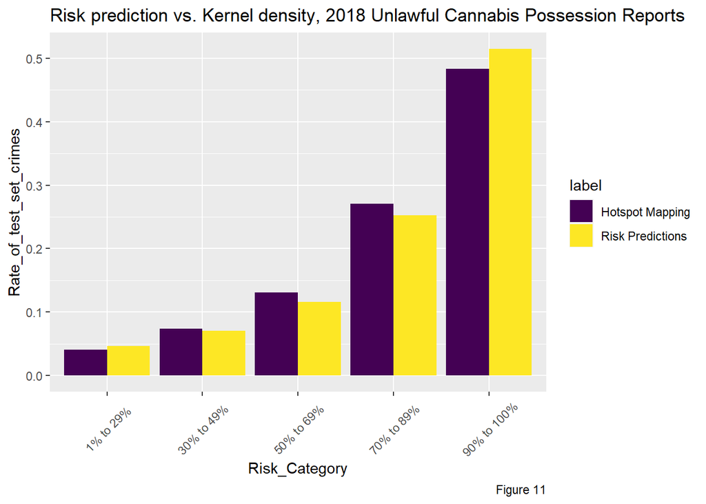

```r
# 11. The bar plot making these comparisons
rbind(cann_KDE_sf, cann_risk_sf) %>%
  st_set_geometry(NULL) %>% na.omit() %>%
  gather(Variable, Value, -label, -Risk_Category) %>%
  group_by(label, Risk_Category) %>%
  summarize(countCann = sum(Value)) %>%
  ungroup() %>%
  group_by(label) %>%
  mutate(Rate_of_test_set_crimes = countCann / sum(countCann)) %>%
    ggplot(aes(Risk_Category,Rate_of_test_set_crimes)) +
      geom_bar(aes(fill=label), position="dodge", stat="identity") +
      scale_fill_viridis(discrete = TRUE) +
      labs(title = "Risk prediction vs. Kernel density, 2018 Unlawful Cannabis Possession Reports", caption="Figure 11") +
      theme(axis.text.x = element_text(angle = 45, vjust = 0.5))
```

Figure 11 shows that the Risk Predictions model captures a greater share of 2018 observations than the Hotspot Mapping model in the highest risk category (90% to 100%). This indicates that the Risk Predictions model is better fit than the business as usual approach.

# Conclusions

While our Risk Prediction model has minimal errors and there is evidence that it is generalizable across neighborhoods, I would not recommend this algorithm be put into production. The model was created on a foundation of many selection biases and is not proactive enough to allocate resources or funding such that crimes are prevented. Rather, the model simply reacts to past conditions and paints a picture of the future assuming conditions stay stagnant.

Selection bias is present in the assumptions made when identifying risk factors. The design relies on the Broken Windows Theory to distinguish physical locations that may be more susceptible to crime. In a big city such as Chicago, it is easy to identify these neighborhoods by their physical appearance. The broken windows, abandoned cars, presence of graffiti, and other poorly maintained buildings are indicators that often make people uneasy and thus have become social indicators of danger. Additionally, historically racist processes such as redlining has forced black and brown individuals to be equated with these under-resourced neighborhoods. These racial prejudices have driven black and brown neighborhoods to be over-policed resulting in seemingly high crime rates in these same neighborhoods as more police presence results in more arrests and reports. This faulty and biased data collection is one major issue with policing prediction models. Instead of crime being equated with genuine areas of high risk, crime is often equated with areas of high police presence.

Further, this model would not be effective or useful to any city because of the fluid nature of recreational marijuana usage and sales over the past 5 years. The laws differ across states and are enforced differently by police across county and even smaller scale boundaries. In some instances, the law is even more narrowly varied as businesses and property owners can dictate whether possession is allowed on their properties. This furthers the notion that predicting outcomes in complex urban systems is extremely difficult. I would argue that predicting crime in a city is still too complex and big in scale. Perhaps, narrowing the global geographic scale to the police district level and identifying factors that drive crime reporting would result in a more proactive approach to policing.